# R Notebook

## Package Management

```r
installed.packages()
```

```r
#install.packages("vegan", dependencies = TRUE) #Already installed
```

```r
library(vegan)
```

```r
#remove.packages()
```

## Project Management

1. Set up management structure (i.e., “data”, “src”, “results”, “doc”)
2. Discuss avoiding redundancy of files
3. Make sure to use version control (i.e., Git)

## Getting Help

```r
?plot
```

```r
help(plot)
```

```r
?"<-"
```

```r
vignette("FAQ-vegan")
```

```r
citation("vegan")
```

## Data and their formats

```r
cats <- data.frame(coat = c("calico", "black", "tabby"),
                   weight = c(2.1,5,3.2),
                   likes_string = c(1,0,1))
```

```r
cats
```

```r
write.csv(cats, file = "~/GitHub/biol48006220_Fall2022/practcomp_2022/data/cats.csv")
```

```r
cats$coat
```

```r
cats$weight
```

```r
cats$weight*10
```

```r
log(cats$weight)
```

```r
logweight <- log(cats$weight)
cbind(cats, logweight)
```

```r
cats <- cbind(cats, logweight)
```

```r
paste("My cat is ", cats$coat, ", and it weighs ", cats$weight, " kg.", sep = "")
```

### Data Types

```r
typeof(cats$coat)
```

```r
typeof(cats$weight)
```

```r
typeof(cats$likes_string)
```

```r
typeof(3.14159)
```

```r
typeof(1i)
```

```r
typeof(FALSE)
```

```r
typeof(T)
```

```r
typeof(cats)
```

```r
class(cats)
```

```r
file.show("./data/cats.csv")
```

```r
cats$likes_string <- as.logical(cats$likes_string)
typeof(cats$likes_string)
```

```r
cats$likes_string
```

```r
c("a", "b")
```

```r
ab <- c("a", "b")
ab
```

```r
c(ab, "c")
```

```r
c(ab, ab)
```

```r
1:10
```

```r
seq(10)
```

```r
z <- seq(10)
head(z, n=3)
```

```r
length(z)
```

```r
class(z)
```

```r
typeof(z)
```

```r
seq(0,100, by=5)
```

### Data Frames

```r
cats
```

```r
str(cats$coat)
```

```r
coats <- c("tabby", "tortoiseshell", "tortoiseshell", "black", "tabby")
coats
```

```r
str(coats)
```

```r
factor(coats)
```

```r
categories <- factor(coats)
class(coats)
class(categories)
```

```r
str(categories)
```

### Lists

```r
list_example <- list(title="Numbers", numbers = 1:10, data=T)
```

```r
list_example
```

```r
another_list <- list(1, "a", TRUE, 1+1i)
another_list
```

```r
typeof(list_example)
class(list_example)
```

```r
typeof(cats)
class(cats)
```

```r
data.frame(list_example)
```

```r
cats
cats[,3]
cats[3,]
```

```r
cats[2:3, c(1,3)]
```

### Matrices

```r
matrix_example<- matrix(0,ncol=5, nrow=3)
```

```r
matrix_example
```

```r
class(matrix_example)
```

```r
typeof(matrix_example)
```

```r
str(matrix_example)
```

```r
dim(matrix_example)
ncol(matrix_example)
nrow(matrix_example)
```

the dim() function will tell you info on the shape

```r
class(data.frame(matrix_example))
```

This will make it in to a df

```r
df_example<- data.frame(matrix_example)
df_example
```

now it’s saved as a df

### Subsetting

```r
p <-c(2.3, 6.9,4.0,23,1)
p
```

```r
names(p)<- c('a','b','c','d','e')
p
```

```r
p[1]
```

```r
p[2:4]
```

```r
p[c(1,5)]
```

```r
p[c(1,1,1,3,5,5)]
```

```r
p[6]
```

out of range items will not crash your script

```r
p[-3]
```

the above code gives you everything besides 3

```r
p[-(2:4)]
```

above code is how you drop a range

```r
p[c('a','c')]
```

```r
p[c(T,F,T,T,F)]
```

T = give data point F= leave out data point

```r
p[names(p) !='c']
```

### Factors

```r
f <- factor(c('a','b','c','d','e'))
f
```

```r
f[f=='a']
```

Above code gives you f where it is equal to a. This can be useful in for loops

```r
f[1:3]
```

```r
f[f %in% c('b','c')]
```

```r
f[-3]
```

```r
f2<- c('a','a','b','c','c')
f2
```

```r
f2[f2=='a']
```

```r
f2[f2 %in% c('a','c')]
```

%in% means “search in here for this”

### matrices resumed

```r
set.seed(65)
m <- matrix(rnorm(6*4),ncol=4, nrow=6)
m
```

#set seed ensures consistency when “randomly” generating seeds. People can reproduce your results

```r
m[3:4, c(3,1)]
```

###lists revisited

```r
xlist <-list(a="BIOL48006220", b=seq(1,10, by = 0.5), data = "Grade")
xlist
```

```r
xlist[1:2]
```

```r
xlist['a']
```

```r
xlist['b']
```

##gives as a sublist

```r
xlist[['b']]
```

the double bracket is used to call in

```r
xlist$b
```

### Data Frames revisited

```r
getwd()
```

```r
gp <- read.csv('./data/forest_area_sq_km.csv')
head(gp, n=10L)
```

```r
head(gp[3], n=10L)
```

```r
nrow(gp)
```

```r
head(gp[["ï..country"]],10L)
```

```r
gp$X2001
```

```r
gp[1:3, 2:5]
```

row, columns

```r
gp[ which(gp$X1989 <= 100 & gp$X2019 >= 100 ), ]
```

### Conditionals and Flow

```r
n <- 10

if (n<10) {
  print("n is less than 10")
} else if (n >10 ){
  print("n is greater than 10")
} else {
  print("n is equal to 10")
}
```

```r
for (n in seq(1,20)){
  if (n<10) {
  print("n is less than 10")
} else if (n >10 ){
  print("n is greater than 10")
} else {
  print("n is equal to 10")
}
}
```

```r
g<- 0

while(g <= 10){
  print(paste(g, "is less than or equal to 10"))
  g <- g+1
}
```

## Plotting and Figures

```r
#install.packages("ggplot2")
```

```r
library(ggplot2)
```

```r
forestdata<-read.csv('./data/forest_area_sq_km.csv')
```

```r
ggplot(data=forestdata, mapping=aes(x=X1989, y=X2019))+geom_point()
```

```r
gp <-read.csv('./data/gapminder_all.csv')

head(gp)
```

|  | continent | country | gdpPercap_1952 | gdpPercap_1957 | gdpPercap_1962 | gdpPercap_1967 | gdpPercap_1972 | gdpPercap_1977 | gdpPercap_1982 | gdpPercap_1987 | gdpPercap_1992 | gdpPercap_1997 | gdpPercap_2002 | gdpPercap_2007 | lifeExp_1952 | lifeExp_1957 | lifeExp_1962 | lifeExp_1967 | lifeExp_1972 | lifeExp_1977 | lifeExp_1982 | lifeExp_1987 | lifeExp_1992 | lifeExp_1997 | lifeExp_2002 | lifeExp_2007 | pop_1952 | pop_1957 | pop_1962 | … |
| --- | --- | --- | --- | --- | --- | --- | --- | --- | --- | --- | --- | --- | --- | --- | --- | --- | --- | --- | --- | --- | --- | --- | --- | --- | --- | --- | --- | --- | --- | --- |
| 1 | Africa | Algeria | 2449.0082 | 3013.9760 | 2550.8169 | 3246.9918 | 4182.6638 | 4910.4168 | 5745.1602 | 5681.3585 | 5023.2166 | 4797.2951 | 5288.0404 | 6223.3675 | 43.077 | 45.685 | 48.303 | 51.407 | 54.518 | 58.014 | 61.368 | 65.799 | 67.744 | 69.152 | 70.994 | 72.301 | 9279525 | 10270856 | 11000948 | … |
| 2 | Africa | Angola | 3520.6103 | 3827.9405 | 4269.2767 | 5522.7764 | 5473.2880 | 3008.6474 | 2756.9537 | 2430.2083 | 2627.8457 | 2277.1409 | 2773.2873 | 4797.2313 | 30.015 | 31.999 | 34.000 | 35.985 | 37.928 | 39.483 | 39.942 | 39.906 | 40.647 | 40.963 | 41.003 | 42.731 | 4232095 | 4561361 | 4826015 | … |
| 3 | Africa | Benin | 1062.7522 | 959.6011 | 949.4991 | 1035.8314 | 1085.7969 | 1029.1613 | 1277.8976 | 1225.8560 | 1191.2077 | 1232.9753 | 1372.8779 | 1441.2849 | 38.223 | 40.358 | 42.618 | 44.885 | 47.014 | 49.190 | 50.904 | 52.337 | 53.919 | 54.777 | 54.406 | 56.728 | 1738315 | 1925173 | 2151895 | … |
| 4 | Africa | Botswana | 851.2411 | 918.2325 | 983.6540 | 1214.7093 | 2263.6111 | 3214.8578 | 4551.1421 | 6205.8839 | 7954.1116 | 8647.1423 | 11003.6051 | 12569.8518 | 47.622 | 49.618 | 51.520 | 53.298 | 56.024 | 59.319 | 61.484 | 63.622 | 62.745 | 52.556 | 46.634 | 50.728 | 442308 | 474639 | 512764 | … |
| 5 | Africa | Burkina Faso | 543.2552 | 617.1835 | 722.5120 | 794.8266 | 854.7360 | 743.3870 | 807.1986 | 912.0631 | 931.7528 | 946.2950 | 1037.6452 | 1217.0330 | 31.975 | 34.906 | 37.814 | 40.697 | 43.591 | 46.137 | 48.122 | 49.557 | 50.260 | 50.324 | 50.650 | 52.295 | 4469979 | 4713416 | 4919632 | … |
| 6 | Africa | Burundi | 339.2965 | 379.5646 | 355.2032 | 412.9775 | 464.0995 | 556.1033 | 559.6032 | 621.8188 | 631.6999 | 463.1151 | 446.4035 | 430.0707 | 39.031 | 40.533 | 42.045 | 43.548 | 44.057 | 45.910 | 47.471 | 48.211 | 44.736 | 45.326 | 47.360 | 49.580 | 2445618 | 2667518 | 2961915 | … |

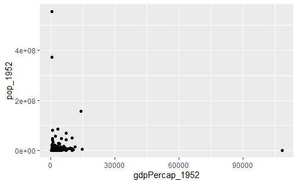

```r
ggplot(data=gp, mapping=aes(x=gdpPercap_1952, y=pop_1952 )) + geom_point()
```

```r
gapminder <- read.csv("https://raw.githubusercontent.com/swcarpentry/r-novice-gapminder/gh-pages/_episodes_rmd/data/gapminder_data.csv")

head(gapminder)
```

|  | country | year | pop | continent | lifeExp | gdpPercap |
| --- | --- | --- | --- | --- | --- | --- |
| 1 | Afghanistan | 1952 | 8425333 | Asia | 28.801 | 779.4453 |
| 2 | Afghanistan | 1957 | 9240934 | Asia | 30.332 | 820.8530 |
| 3 | Afghanistan | 1962 | 10267083 | Asia | 31.997 | 853.1007 |
| 4 | Afghanistan | 1967 | 11537966 | Asia | 34.020 | 836.1971 |
| 5 | Afghanistan | 1972 | 13079460 | Asia | 36.088 | 739.9811 |
| 6 | Afghanistan | 1977 | 14880372 | Asia | 38.438 | 786.1134 |

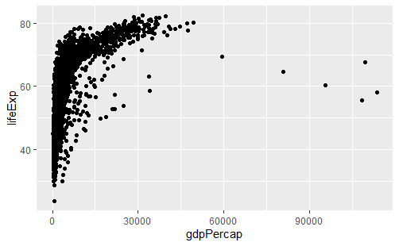

```r
ggplot(data=gapminder, mapping=aes(x=gdpPercap, y=lifeExp)) + geom_point()
```

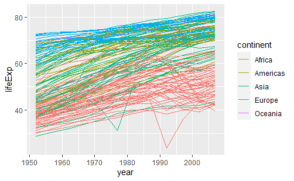

```r
ggplot(data=gapminder, mapping=aes(x=year, y=lifeExp, by=country, color=continent)) + geom_line()
```

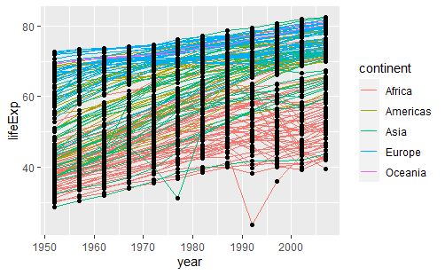

```r
ggplot(data=gapminder, mapping=aes(x=year, y=lifeExp, by=country)) + geom_line(mapping=aes(color=continent))+geom_point()
```

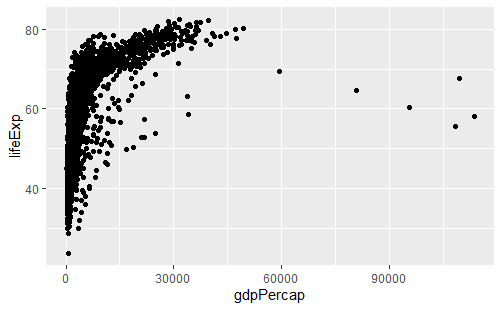

```r
ggplot(data=gapminder, mapping=aes(x=gdpPercap, y=lifeExp))+ geom_point()
```

# this data needs to be log transformed

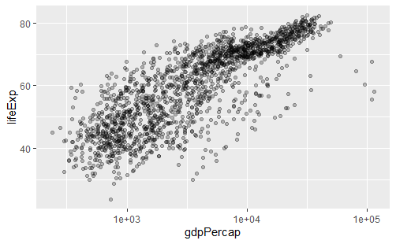

```r
ggplot(data=gapminder, mapping=aes(x=gdpPercap, y=lifeExp))+ geom_point(alpha=0.25) + scale_x_log10()
```

Now you can run linear regression model alpha= transparency of data point

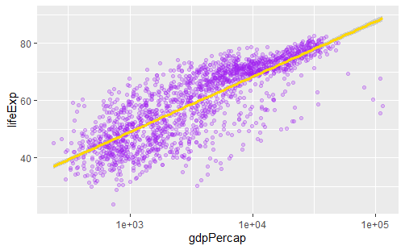

```r
ggplot(data=gapminder, mapping=aes(x=gdpPercap, y=lifeExp))+ geom_point(alpha=0.25, color="purple") + scale_x_log10()+ geom_smooth(method=lm, color="gold", size= 1.25)
```

```r
africas<- gapminder[gapminder$continent=="Africa",]
head(africas)
```

|  | country | year | pop | continent | lifeExp | gdpPercap |
| --- | --- | --- | --- | --- | --- | --- |
| 25 | Algeria | 1952 | 9279525 | Africa | 43.077 | 2449.008 |
| 26 | Algeria | 1957 | 10270856 | Africa | 45.685 | 3013.976 |
| 27 | Algeria | 1962 | 11000948 | Africa | 48.303 | 2550.817 |
| 28 | Algeria | 1967 | 12760499 | Africa | 51.407 | 3246.992 |
| 29 | Algeria | 1972 | 14760787 | Africa | 54.518 | 4182.664 |
| 30 | Algeria | 1977 | 17152804 | Africa | 58.014 | 4910.417 |

[figure not shown]

```r
ggplot(data=africas, mapping= aes(x=year, y=lifeExp))+geom_line()+ facet_wrap( ~country) + theme(axis.text.x= element_text(angle=90)) +
  labs(
    x= "year",
    y="life expectancy",
    title= "Life Expectancy Over Time in African Countries"
  )
```

```r
NA
```

```r
AfricanLifeExp <- ggplot(data=africas, mapping= aes(x=year, y=lifeExp))+geom_line()+ facet_wrap( ~country) + theme(axis.text.x= element_text(angle=90)) +
  labs(
    x= "year",
    y="life expectancy",
    title= "Life Expectancy Over Time in African Countries"
  )
```

now your graph is saved as an object

```r
ggsave(filename= "data/AfricanLifeExp.png", plot =AfricanLifeExp, width = 24, height = 40, dpi =300, units="cm")
```

```r
pdf(file= "results/AfricanLifeExp.pdf", width = 24, height = 40)
plot(AfricanLifeExp)
dev.off()
```

must turn developer mode off, this is how you get figures out of R

```r
write.table(gapminder, file="data/gapminder_web.csv", sep=",")
```

```r
write.csv(africas, file="data/gapminder_web_africas.csv")
```

```r
install.packages(c("gridges","viridis", "hrbrthemes"), dependencies = T)
```

[output not shown]

[output not shown]

[output not shown]

[output cut: 915 more lines]

[output not shown]

r graph gallery

## Stats

### Additional ways of importing the data

```r
rand<- c(12,54,98,65,38)
```

```r
rand
```

```r
sum(rand)
```

```
[1] 267
```

```r
length(rand)
avg(rand)
mean(rand)
sort(rand)
min(rand)
max(rand)
cumsum(rand)
diff(rand)
rand[2]
rand*2
```

```r
pedes <- scan()
j
```

^^can be used to copy and paste data into a df

### Analyses

#### Univariate Statistics

1. Categorical data
1. Barplots

```r
beer <- c(3,4,1,1,3,4,3,1,3,2,1,2,1,2,1,1,1,4,3,1)
```

```r
barplot(table(beer), xlab="beer", ylab="Frequency") #counts
```

```r
barplot(table(beer)/length(beer), xlab)

#unfinished
```

```r
pie(table(beer), main="beer preference")
```

2.Numerical data a. stem and leaf plots

```r
stem(pedes)
```

```r
stripchart(pedes,method="stack")
```

3. Measures of Center
1. mean

```r
mean(pedes)
```

2. Median

```r
median(pedes)
median(gapminder$country)
```

```r
with(gapminder, median(lifeExp))
```

c.mode

```r
which(table(pedes)==max(table(pedes)))
```

4. variation a.range

```r
range(pedes)
```

2. variance

```r
var(pedes)
```

IqR

```r
IQR(pedes)
```

4. z scores

```r
scale(pedes)
```

what are z score- # of SD away from mean

5. Summary

```r
Summary(pedes)
```

histogram

```r
hist(pedes)
```

5. Plotting
1. histograms

```r
hist(pedes, breaks="scott")
#scott creates a nice number of breaks

hist(pedes, breaks="scott", prob=TRUE)
#will plot probability

hist(pedes, breaks="scott", prob=TRUE)
lines(density(pedes))
```

box plots

```r
boxplot(pedes)

summary(boxplot(pedes))
#aka
summary(pedes)
```

#### Bivariate and Multivariate Statistics

1. plotting and regression

```r
spid.gen <- read.csv("data/spider_genitalia.csv", header = T )
```